# MachLearnProj

Amy

October 24, 2015

Six young health participants were asked to perform one set of 10 repetitions of the Unilateral Dumbbell Biceps Curl in five different fashions: exactly according to the specification (Class A), throwing the elbows to the front (Class B), lifting the dumbbell only halfway (Class C), lowering the dumbbell only halfway (Class D) and throwing the hips to the front (Class E). Class A corresponds to the specified execution of the exercise, while the other 4 classes correspond to common mistakes.

Velloso, E.; Bulling, A.; Gellersen, H.; Ugulino, W.; Fuks, H. Qualitative Activity Recognition of Weight Lifting Exercises. Proceedings of 4th International Conference in Cooperation with SIGCHI (Augmented Human ’13) . Stuttgart, Germany: ACM SIGCHI, 2013.

```r
library(caret)
library(AppliedPredictiveModeling)
library(randomForest)
library(e1071) #Error in requireNamespaceQuietStop("e1071") : package e1071 is required
```

Download and read-in the training and testing data

```r
# download and read in the training and testing data
url1<-"http://d396qusza40orc.cloudfront.net/predmachlearn/pml-training.csv"
trainDat <- read.csv(url(url1), na.strings=c("NA","#DIV/0!",""))
url2<-"http://d396qusza40orc.cloudfront.net/predmachlearn/pml-testing.csv"
testDat <- read.csv(url(url2), na.strings=c("NA","#DIV/0!",""))
```

Remove NA’s and variables that will not aid in prediction (id’s, timestamps, etc)

```r
naVector <-vector()
for(i in 1:length(trainDat)) {
  if(any(is.na(trainDat[, i]))) {
    naVector<-c(naVector,i)
  }
}
trainDat<-trainDat[,-naVector]

trainDat<-trainDat[,-c(1:7)]
```

Set the seed and divide the dataset into 3 so we can have test, train & validation sets

```r
#Set seed
set.seed(1000)

#First divide
inTrain <- createDataPartition(trainDat$classe, p=0.6, list=FALSE)
myTrain <- trainDat[inTrain, ]
crossVal <- trainDat[-inTrain,]

#Second divide
inTrain <- createDataPartition(crossVal$classe, p = 0.5, list=FALSE)
myTest<-crossVal[-inTrain,]
crossVal<-crossVal[inTrain,]

dim(myTrain);dim(myTest);dim(crossVal)
```

```
## [1] 11776    53
```

```
## [1] 3923   53
```

```
## [1] 3923   53
```

At the recommendation of the discussion forums, using random forests with cross - validation for model.

```r
randForFit <- randomForest(classe ~. , data=myTrain)

# Final Model
randForPred <- predict(randForFit, crossVal)
confusionMatrix(randForPred, crossVal$classe)
```

```
## Confusion Matrix and Statistics
##
##           Reference
## Prediction    A    B    C    D    E
##          A 1113    9    0    0    0
##          B    3  746    7    0    0
##          C    0    4  677   15    0
##          D    0    0    0  628    3
##          E    0    0    0    0  718
##
## Overall Statistics
##
##                Accuracy : 0.9895
##                  95% CI : (0.9858, 0.9925)
##     No Information Rate : 0.2845
##     P-Value [Acc > NIR] : < 2.2e-16
##
##                   Kappa : 0.9868
##  Mcnemar's Test P-Value : NA
##
## Statistics by Class:
##
##                      Class: A Class: B Class: C Class: D Class: E
## Sensitivity            0.9973   0.9829   0.9898   0.9767   0.9958
## Specificity            0.9968   0.9968   0.9941   0.9991   1.0000
## Pos Pred Value         0.9920   0.9868   0.9727   0.9952   1.0000
## Neg Pred Value         0.9989   0.9959   0.9978   0.9954   0.9991
## Prevalence             0.2845   0.1935   0.1744   0.1639   0.1838
## Detection Rate         0.2837   0.1902   0.1726   0.1601   0.1830
## Detection Prevalence   0.2860   0.1927   0.1774   0.1608   0.1830
## Balanced Accuracy      0.9971   0.9899   0.9920   0.9879   0.9979
```

Then predict model on test dataset.

```r
randForPred2 <- predict(randForFit, myTest)
confusionMatrix(myTest$classe, randForPred2)
```

```
## Confusion Matrix and Statistics
##
##           Reference
## Prediction    A    B    C    D    E
##          A 1115    1    0    0    0
##          B    9  748    2    0    0
##          C    0    2  681    1    0
##          D    0    0    6  637    0
##          E    0    0    1    0  720
##
## Overall Statistics
##
##                Accuracy : 0.9944
##                  95% CI : (0.9915, 0.9965)
##     No Information Rate : 0.2865
##     P-Value [Acc > NIR] : < 2.2e-16
##
##                   Kappa : 0.9929
##  Mcnemar's Test P-Value : NA
##
## Statistics by Class:
##
##                      Class: A Class: B Class: C Class: D Class: E
## Sensitivity            0.9920   0.9960   0.9870   0.9984   1.0000
## Specificity            0.9996   0.9965   0.9991   0.9982   0.9997
## Pos Pred Value         0.9991   0.9855   0.9956   0.9907   0.9986
## Neg Pred Value         0.9968   0.9991   0.9972   0.9997   1.0000
## Prevalence             0.2865   0.1914   0.1759   0.1626   0.1835
## Detection Rate         0.2842   0.1907   0.1736   0.1624   0.1835
## Detection Prevalence   0.2845   0.1935   0.1744   0.1639   0.1838
## Balanced Accuracy      0.9958   0.9963   0.9930   0.9983   0.9998
```

```r
error <- 1 - as.numeric(confusionMatrix(myTest$classe, randForPred2)$overall[1])
```

Use rplot.plot package to view decision tree visualization

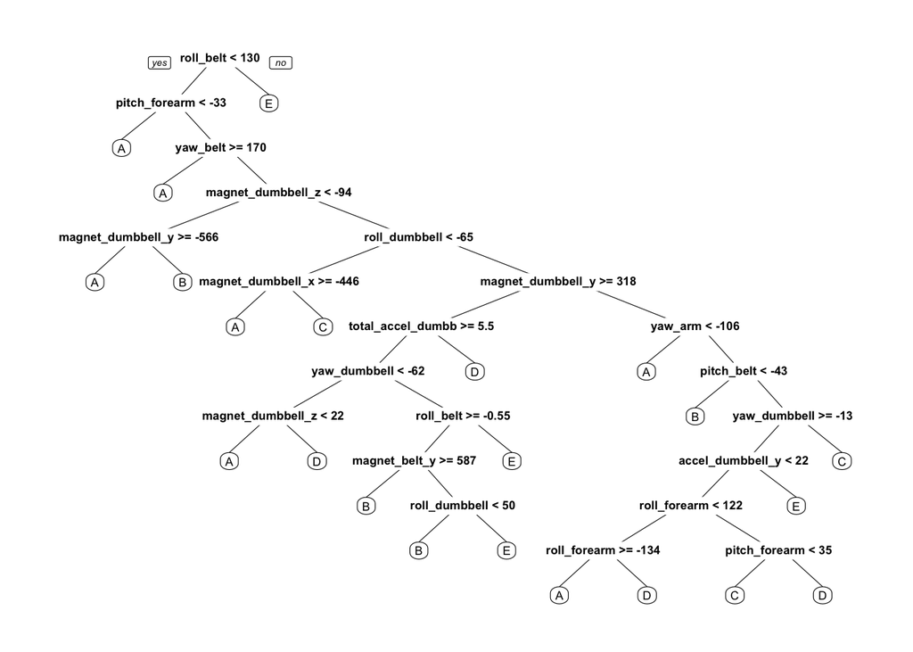

```r
library(rpart)
library(rpart.plot)
treeModel <- rpart(classe ~ ., data=myTrain, method="class")
prp(treeModel) # plot of Tree Model
```